# Introdução ao R Commander

## Saindo e retornando ao R Commander

### Desligando o R Commander

Saber sair corretamente do programa é importante. O mais normal é fechar a interface gráfica e o terminal, utilizando:

$\ $Arquivo ->Sair ->Do Commander e do R  
$\ $File -> Exit -> From R Commander and R

O programa perguntará se quer salvar o script e o output. Por enquanto responda **[Não]** (**[No]**) para ambos; voltaremos a isto adiante.

### Voltando ao R Commander

Nas seções anteriores você abriu dois data sets e os salvou. O primeiro, **Exames1**, foi obtido de um arquivo texto que geramos a partir de uma planilha do Excel; o segundo, **Colegas**, foi digitado por você. Respectivamente, devem ter sido salvos no formato do Rcmdr com os nomes **Exames1.Rdata** e **Colegas.Rdata**.

Reabra, portanto, o Rcmdr e utilize:

$\ $Dados -> Carregar conjunto de dados...

$\ $Data -> Load data set

aponte para leitura o arquivo **Exames1.Rdata**. A seguir, repita o procedimento para ler **Colegas.Rdata**. Repare a *Script Window* onde aparece

```
load("{aqui aparece o caminho para seu arquivo}/Exames1.RData")
load("{aqui aparece o caminho para seu arquivo}/Colegas.RData")
```

### Salvando e lendo scripts

Este é um uso mais avançado e este exemplo é muito simples (mas ilustrativo).

Pois bem... utilize:

$\ $Arquivo -> salvar script como ...  
$\ $File -> Save script as...  
e dê o nome **Leitura_Exames_e_Colegas.R** para este script.

Feche completamente o programa (**Sair -> Do Commander e do R, Exit -> From Commander and R**) e abra novamente. Utilize

$\ $Arquivo -> Abrir arquivo c/ script  
$\ $File -> Open script file...

e traga de volta o conteúdo da Janela script (Script Window) recuperando o arquivo **Leitura_Exames_e_Colegas.R**. Repare que esta janela permite edição, de forma que você pode conferir e ajeitar o script sempre que quiser. Quanto estiver pronto, note o botão **Submeter** (**Submit**) no canto inferior direito desta janela: clique nele para executar seu script. A janela mensagens (Messages) mostra:

ERRO: Nada foi selecionado.  
ERROR: Nothing is selected.

Selecione, então, na Janela Script (*Script Window*) as duas linhas:

```
load("{aqui aparece o caminho para seu arquivo}/Exames1.RData")
load("{aqui aparece o caminho para seu arquivo}/Colegas.RData")
```

e clique em **Submeter** (**Submit**) novamente. Desta vez a Janela output (Output Window) reage, mostrando

```
> load("{aqui aparece o caminho para seu arquivo}//Exames1.RData")
> load("{aqui aparece o caminho para seu arquivo}//Colegas.RData")
```

NOTA: Os dados Exames1 tem 705 linhas e 15 colunas.  
NOTE: The dataset Exames1 has 705 rows and 15 columns.

ou

NOTA: Os dados Colegas tem 3 linhas e 3 colunas.  
NOTE: The dataset Colegas has 3 rows and 3 columns.

de acordo com o conjunto de dados que você deixou ativo.

A partir deste exemplo simples, sofistique. Qualquer script que você salvar, reler e submeter repetirá uma sequência de ações. Com o que aprender adiante, poderá trabalhar no R Commander experimentando fazer alguma análise. Apague as linhas que não deram certo. faça coisas algo mais sofisticadas, como gráficos e análises estatísticas, teste com determinado conjunto de dados e, depois, adapte o script para repetir o trabalho em outros conjuntos de dados. Salve seus scripts "amadurecidos" e evitará um monte de (re)trabalho.

Similar, mas menos útil (pois não roda como um script), caso queira preservar um lembrete do que fez enquanto usava o Rcmdr, é salvar a Janela Output(Output Window) em um arquivo texto.

## Manipulação da Planílha

Há uma quantidade de operações disponíveis nos menus do R Commander. Aqui ilustraremos algumas, que lhe permitirão:

- criar subsets
- fazer gráficos

### Obtendo subconjunto dos dados

**Importante**: Antes de começar o exercício proposto aqui, observe que na versão xls, da qual os dados de **Exames1** vieram, a coluna de sódio sérico tem o nome de variável NA. Embora a importação ocorra sem problemas, o nome da variável entra em conflito com a palavra reservada do Rcmdr, **NA**, significando **N**ot **A**vailable (confira com **[View data set]**: aparece um pequeno ponto ao lado de **NA**). É possível consertar o arquivo texto e reimportar os dados, mas a solução mais simples e rápida, agora que já importou os dados, é entrar no modo de preenchimento manual da planilha, alterar o nome da variavel (por exemplo, para **SODIO** ou **Natremia** - evitando começar com **NA** em maiúsculas) e, então, salvar seu data set novamente, para preservar a modificação. Outra maneira de fazer a mesma coisa é usar **Dados -> modificação de variáveis no conjunto de dados -> Renomear variáveis... (Data -> Manage variables in active data set -> Rename variables...)**.

Uma vez consertado e ativo seu data set **Exames1**, utilize:

$\ $Dados -> Conjunto de dados ativos -> definir subconjunto de dados ativos...  
$\ $Data -> Active data set -> Subset active data set...  
Observe a janela que se abre:

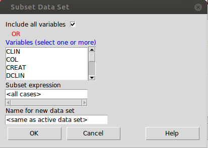

É possível "recortar" colunas ou linhas do data set.

### Escolhendo colunas

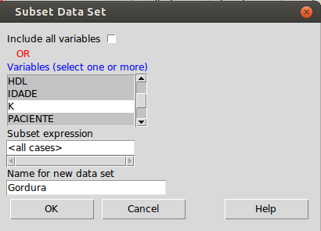

Clique **[OK]**. Na **Janela de Script** (**Script Window**) aparece o comando:

Gordura <- subset(Exames1, select=c(COL,HDL,IDADE,PACIENTE,SEXO,TRIG))

Na Output Window ecoa-se a execução do comando R:

```
Gordura <- subset(Exames1, select=c(COL,HDL,IDADE,PACIENTE,SEXO,TRIG))
```

Na janela mensagens (Message Window) o sistema notifica:

NOTA: os dados Gordura tem 705 linhas e 6 colunas.  
NOTE: The dataset Gordura has 705 rows and 6 columns.

o que confere, pois todos os pacientes foram transferidos (mesmo número de linhas do conjunto original), mas com apenas 6 colunas. Repare que o conjunto de dados ativo agora é Gordura; como sempre, você pode conferir com **[Ver conjunto de dados]** (*[View data set]*) e salvar seu conjunto de dados em um arquivo **Gordura.Rdata** para uso futuro.

### Escolhendo linhas

#### Variáveis numéricas

Torne o data set **Exames1** novamente ativo e repita o processo para fazer um Subconjunto (subset). Podemos, por exemplo, separar os pacientes com hipernatremia (sódio sérico acima de 142 mEq/L). Desta vez vamos deixar assinalado **Incluir todas as variáveis** (*Include all variables*), portanto não há sentido em apontar nada no quadro de variáveis, e colocaremos em **Expressão** (*Subset expression*) a expressão **SODIO > 142**. Como sempre, escolheremos um nome para o novo data set que seja significativo (e.g. Hipernatremicos).

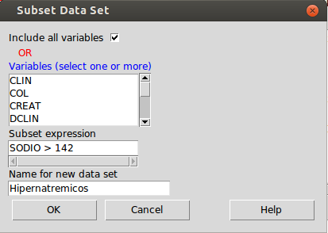

Ao clicar [OK] acontecerá algo imprevisto: uma mensagem de alerta (em verde) na Janela de mensagem (Message Window):

NOTA: Aviso em Ops.factor(SODIO, 142) : > não faz sentido para fatores  
WARNING: Warning in Ops.factor(SODIO, 142) : > not meaningful for factors

Por que? Esta coluna de **SODIO**, que já tínhamos renomeado, ainda tem problemas. Neste caso, volte a ativar o conjunto de dados Exames1, entre no editor de dados clicando **[Editar conjunto de dados]** (**[Edit data set]**) e clique sobre o nome da variável **SODIO**. Há um asterisco em frente da palavra Character (character)

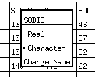

compare com a coluna do potássio sérico:

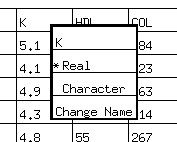

que é *Real*. Respectivamente significa que **SODIO**, por alguma razão, está sendo tratada pelo Rcmdr como texto, enquanto K é numérica. Para corrigir, basta indicar que **SODIO** é *Real*, sair do editor e repetir a geração do sub set chamado **Hipernatremicos**. Desta vez, na Mensagens (Message Window), aparece:

NOTA: Os dados Hipernatremicos tem 25 linhas e 15 colunas.  
NOTE: The dataset Hipernatremicos has 25 rows and 15 columns.

NOTA: OS dados Normonatremicos tem 678 linhas e 15 colunas.  
NOTE: The dataset Normonatremicos has 678 rows and 15 columns.

NOTA: Os dados Hiponatremicos tem 1 linhas e 15 colunas.  
NOTE: The dataset Hiponatremicos has 1 rows and 15 columns.

Que tal verificar as demais colunas, se estão registradas como numéricas e textuais como deviam ser? Uma sugestão: dê uma olhada em GLIC na linha 144, que tem um * (aceitável para uma variável contendo texto), transforme GLIC em Real e olhe a linha 144 novamente (você deve aprender algo sobre o Rcmdr com isto).

#### Variáveis textuais

Dados textuais (i.e., character) também podem ser utilizados para separar um subset. Suponha que eu queira isolar as mulheres em um subset **Exames1_mulheres**. É o mesmo procedimento (lembre-se de tornar Exames1 novamente ativo), utilizando a **Expressão** (**Subset expression**) como **SEXO == "F"** (note o uso de dois sinais de igual, sintaxe do R para comparações lógicas pois o sinal de igual simples serve para atribuições, e F entre aspas porque é uma string), obtendo.

NOTA: Os dados Exames1_mulheres tem 448 linhas e 15 colunas.  
NOTE: The dataset Exames1_mulheres has 448 rows and 15 columns.

#### Mais exemplos?

Enquanto executava as operações acima, você prestou atenção à Script (Script Window)? Se sim, deve ter visto os comandos:

```
Gordura <- subset(Exames1, select=c(COL,HDL,IDADE,PACIENTE,SEXO,TRIG))
Hipernatremicos <- subset(Exames1, subset=SODIO > 142)
Normonatremicos <- subset(Exames1, subset=SODIO >= 120 & SODIO <= 142)
Hiponatremicos <- subset(Exames1, subset=SODIO < 120)
Exames1_mulheres <- subset(Exames1, subset=SEXO == "F")
```

O que aparece após **subset=** são expressões R válidas. Em qualquer site que dê exemplos encontrará outros operadores (como |, barra vertical, que significa **or**). Poderá, com isto, descobrir como construir expressões mais complexas para gerar o subset que precisar.

Veja, por exemplo, [este link](http://rprogramming.net/subset-data-in-r/).

Uma pequena lista dos operadores básicos, úteis para construir as expressões, é

Operadores para expressões em R

| Operador | Significado |  |
| --- | --- | --- |
| $ == $ | igual |  |
| $ != $ | diferente |  |
| $ \text{&} $ | AND |  |
| $ \text{ | } $ | OR |
| $ \text{is.na(nome_da_variável)} $ | **inclui** os valores não disponíveis (NA) da variável |  |
| $ \text{!is.na(nome_da_variável)} $ | **exclui** os valores não disponíveis (NA) da variável |  |
| $ > $ | maior que |  |
| $ < $ | menor que |  |
| $ >= $ | maior ou igual que |  |
| $ <= $ | menor ou igual que |  |

Parênteses também podem ser usados para a precedência de expressões. Por exemplo (absurdo, mas somente para exercitar), se quisermos um *subset* ou subconjunto das mulheres hipernatrêmicas e dos homens normonatrêmicos, poderíamos usar a expressão

```
(SODIO > 142 & SEXO == "F") | ((SODIO >= 120 & SODIO <=142) & SEXO == "M")
```

garantindo, desta forma, que todos os **AND** e **OR** aconteçam na ordem desejada. Se o executar obterá:

```
Exemplo_complicado <- subset(Exames1, subset=(SODIO > 142 & SEXO == "F") | ((SODIO >= 120 & SODIO <=142) & SEXO == "M"))
```

e

NOTA: Os dados Exemplo_complicado tem 257 linhas e 15 colunas.  
NOTE: The dataset Exemplo_complicado has 257 rows and 15 columns.

Use Ver conjunto de dados ([View data set]) e confira; procure as poucas mulheres filtradas e verá que são as hipernatrêmicas.

Outras operações com o subset ativo Dois menus do Rcmdr permitem várias manipulações que podem ser úteis:

$\ $ Dados -> conjunto de dados ativo  
$\ $ Data -> Active data set

e

$\ $ Dados -> Modificação de variáveis no conjunto de dados ativos  
$\ $ Data -> Manage variables in active data set

Seus nomes são o que sugerem, de forma que sugerimos que os explore por sua conta. Aqui daremos apenas alguns exemplos.

Note: embora a planilha no Rcmdr tenha uma organização matricial em colunas e linhas, ela tem uma diferença fundamental em relação às planilhas do Excel, Gnumeric, OpenOffice, LibreOffice e similares: suas células comportam valores, mas não fórmulas. Devido a isso, as operações são realizadas com os conteúdos de colunas e o resultado armazenado em uma coluna escolhida na operação.

#### Veja as variáveis do data set

Use

$\ $ Dados -> Conjunto de dados ativos -> variáveis em conjunto de dados ativo

$\ $ Data -> Active data set -> Variables in active data set

Como sempre, veja o comando R na Script Window e a resposta na Output Window

#### Removendo pacientes da planilha

Em algumas situações a análise é perturbada por dados incorretamente preenchidos ou não preenchidos. Respectivamente experimente

$\ $ Dados -> conjunto de dados ativos -> Remova linha(s) do conjunto de dados ativos...

$\ $ Data -> Active data set -> Remove rows from active data set...

e

$\ $ Dados -> Conjunto de dados ativos -> Remover observações com dados faltantes...

$\ $ Data -> Active data set -> Remove cases with missing data...

Em ambos você tem a opção de fazer a operação no próprio data set em uso, o que pode não ser conveniente caso precise voltar atrás, ou criar um novo, que você pode salvar para uso futuro.

#### Recodificando variáveis

Com

$\ $ Dados -> Modificação de variáveis de conjunto de dados ativo -> Recodificar variáveis...

$\ $ Data -> Manage variables in active data set -> Recode variables...

você pode criar outras variáveis. Por exemplo, caso queiramos classificar as pessoas de acordo com suas idades, experimente:

1 selecionar a variável **IDADE**; 2 escolher o nome da nova variável, e.g. IDADE_classificacao; 3 preencher **Definições p/ recodificação** (*Enter recode directives*) com um critério de sua escolha, e.g.:

```
1:11 = "crianca"
12:17 = "adolescente"
18:25 = "adulto jovem"
26:64 = "adulto"
65:1000 = "idoso"
```

Observe que nova coluna foi adicionada ao seu *data set*.

Existem outras formas de definir as diretivas --- consulte **[Ajuda]** (**[Help]**) antes de clicar **[OK]**.

Experimente "esquecer" um pedaço das idades, por exemplo, parando os adultos aos 55 anos de idade, e observe como ficam os conteúdos da variável criada.

#### Eliminando variáveis

Com

$\ $ Dados -> Modificação de variáveis de conjunto de dados ativo -> Apagar variáveis do conjunto de dados...

$\ $ Data -> Manage variables in active data set -> Delete variables from data set...

você pode retirar colunas inteiras de seus dados, seja porque não quer determinadas colunas para sua análise, ou porque criou uma coluna erradamente. Experimente remover a **IDADE_classificacao** que acabou de criar.

#### Reordenando as colunas

Quando se utiliza o recurso "Definir sub-conjunto de dados ativo",

$\ $ Dados -> Conjunto de dados ativos -> definir subconjunto de dados ativos...

$\ $ Data -> Active data set -> Subset active data set...  
as colunas do novo conjunto de dados serão automaticamente ordenadas na ordem alfabética das variáveis selecionadas.

No exemplo do *data set* **Gordura**, a tabela fica da seguinte forma:

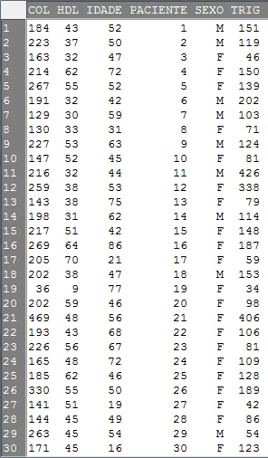

Lembrando que para criar essa tabela o comando utilizado foi:

```
Gordura <- subset(Exames, select=c(COL,HDL,IDADE,PACIENTE,SEXO,TRIG))
library(relimp, pos=4)
```

Observe que a ordem das colunas segue a ordem das variáveis no comando (COL,HDL,IDADE,PACIENTE,SEXO,TRIG). Assim, para reordenar as colunas na tabela, basta alterar a ordem das varáveis no comando. Por exemplo:

```
Gordura <- subset(Exames, select=c(PACIENTE,SEXO,IDADE,COL,HDL,TRIG)) library(relimp, pos=4)
```

Resultando numa apresentação mais ordenada dos dados:

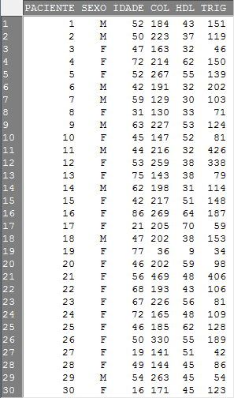

## Para saber mais

Há muitos tutoriais e dicas de uso na Web. Quem encontrar e testar outros, pode no enviar sugestões colocando um breve comentário sobre sua experiência.

### Para iniciantes

[Getting Started with R Commander](http://socserv.mcmaster.ca/jfox/Misc/Rcmdr/Getting-Started-with-the-Rcmdr.pdf):  
Trata-se de um mini-manual de 28 páginas disponível em PDF, escrito por um dos autores do Rcmdr. É indicado para quem vai usar o R Commander pela primeira vez ou precisa de uma recordação rápida sobre seu uso. Começa desde o início básico, explicando todos os elementos da interface do R Commander, e conclue com algumas manipulações básicas dos dados.

## Referências

1 [David McCallum. R Commander HowTo (PDF)](http://www.junction404.com/R_Commander.pdf)  
2 [Fox J. Getting Started with R Commander](http://socserv.mcmaster.ca/jfox/Misc/Rcmdr/Getting-Started-with-the-Rcmdr.pdf)

This page was last modified on 1 September 2016, at 16:38.